# Flexible Damage Functions

Year 2098 · T<sub>mean</sub> across these regions: 2.05°C

| Region | Raw | Flex | Residual |
| --- | --- | --- | --- |
| AIA | 0 | 0 | 0 |
| BLM | 0 | 0 | 0 |
| BMU.R676c07148ce9acd1 | 0 | 0 | 0 |
| CCK | 0 | 0 | 0 |
| CXR | 0 | 0 | 0 |
| LKA.4.Rc00ff64e9e46cf76 | -0.627 | -0.266 | 0.361 |
| MMR.10.35.167 | -0.141 | -0.481 | -0.34 |
| MMR.10.32.157 | -0.156 | -0.49 | -0.334 |
| MMR.10.35.165 | -0.142 | -0.476 | -0.333 |
| MMR.10.35.166 | -0.171 | -0.499 | -0.328 |

**rcp85**

**SSP2**

**high**

**Correlation:** 0.9614 | **RMSE:** 0.175077 | **Sign agreement:** 95.3%

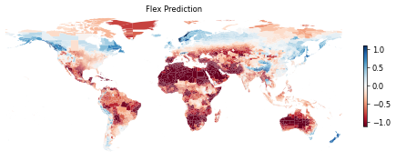

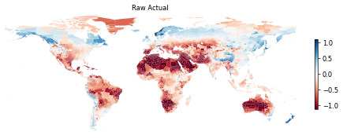

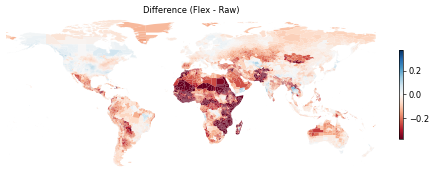

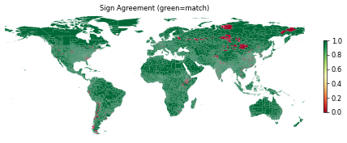

[interactive chart not shown]

Top 5 best predicted Top 5 worst predicted

Year 2098 · T<sub>mean</sub> across these regions: 4.51°C

| Region | Raw | Flex | Residual |
| --- | --- | --- | --- |
| AIA | 0 | 0 | 0 |
| BLM | 0 | 0 | 0 |
| BMU.R676c07148ce9acd1 | 0 | 0 | 0 |
| CCK | 0 | 0 | 0 |
| CXR | 0 | 0 | 0 |
| MLI.4.15 | -0.587 | -1.7 | -1.11 |
| HND.11 | -0.596 | -1.69 | -1.1 |
| MLI.4.14 | -0.453 | -1.52 | -1.07 |
| MOZ.3.33.114 | -0.266 | -1.3 | -1.04 |
| MLI.4.16 | -0.429 | -1.46 | -1.03 |

**low**

**Correlation:** 0.9809 | **RMSE:** 0.125290 | **Sign agreement:** 96.7%

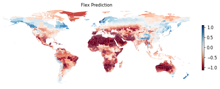

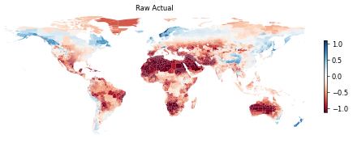

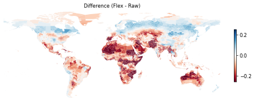

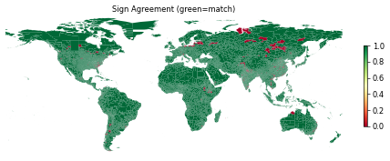

[interactive chart not shown]

Top 5 best predicted Top 5 worst predicted

Year 2098 · T<sub>mean</sub> across these regions: 4.51°C

| Region | Raw | Flex | Residual |
| --- | --- | --- | --- |
| AIA | 0 | 0 | 0 |
| BLM | 0 | 0 | 0 |
| BMU.R676c07148ce9acd1 | 0 | 0 | 0 |
| CCK | 0 | 0 | 0 |
| CXR | 0 | 0 | 0 |
| SOM.10.39 | -0.813 | -1.56 | -0.752 |
| SOM.10.41 | -0.77 | -1.51 | -0.737 |
| ERI.3.15 | -0.673 | -1.39 | -0.713 |
| SOM.5.19 | -0.748 | -1.44 | -0.695 |
| SOM.5.18 | -0.749 | -1.44 | -0.691 |

**SSP3**

**high**

**Correlation:** 0.9807 | **RMSE:** 0.093523 | **Sign agreement:** 95.9%

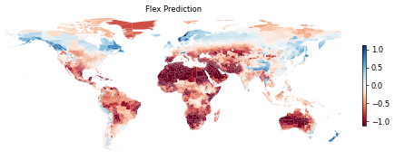

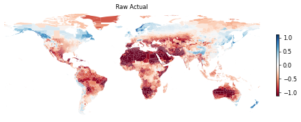

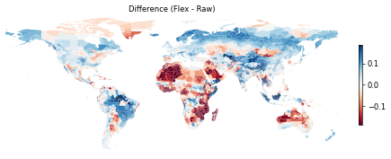

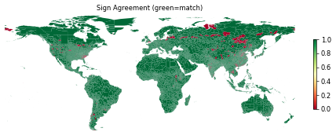

[interactive chart not shown]

Top 5 best predicted Top 5 worst predicted

Year 2098 · T<sub>mean</sub> across these regions: 4.51°C

| Region | Raw | Flex | Residual |
| --- | --- | --- | --- |
| AIA | 0 | 0 | 0 |
| BLM | 0 | 0 | 0 |
| BMU.R676c07148ce9acd1 | 0 | 0 | 0 |
| CCK | 0 | 0 | 0 |
| CXR | 0 | 0 | 0 |
| GUM.Rbf31fb14df17d835 | -0.408 | -1.09 | -0.681 |
| ZWE.8.Raef3712f385d02bc | -0.609 | -1.24 | -0.634 |
| ZWE.10.56 | -0.646 | -1.27 | -0.627 |
| ZWE.10.R6a51f20fce9a50e9 | -0.64 | -1.26 | -0.619 |
| ZWE.10.R8ebd682a94bb3f2c | -0.642 | -1.24 | -0.599 |

**low**

**Correlation:** 0.9765 | **RMSE:** 0.097375 | **Sign agreement:** 96.5%

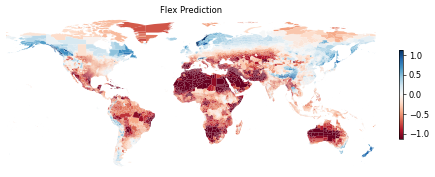

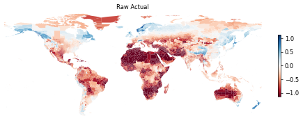

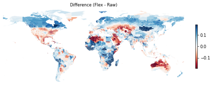

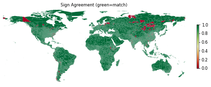

[interactive chart not shown]

Top 5 best predicted Top 5 worst predicted

Year 2098 · T<sub>mean</sub> across these regions: 4.51°C

| Region | Raw | Flex | Residual |
| --- | --- | --- | --- |
| AIA | 0 | 0 | 0 |
| BLM | 0 | 0 | 0 |
| BMU.R676c07148ce9acd1 | 0 | 0 | 0 |
| CCK | 0 | 0 | 0 |
| CXR | 0 | 0 | 0 |
| ZWE.9.46 | -1.76 | -0.831 | 0.929 |
| ZWE.6.29 | -1.44 | -0.515 | 0.924 |
| ZWE.4.R960bd0af211ee36f | -1.43 | -0.526 | 0.901 |
| ZWE.8.39 | -1.45 | -0.568 | 0.882 |
| ZWE.8.41 | -1.62 | -0.748 | 0.873 |

**SSP4**

**high**

**Correlation:** 0.9755 | **RMSE:** 0.145349 | **Sign agreement:** 93.1%

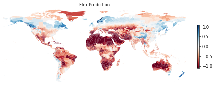

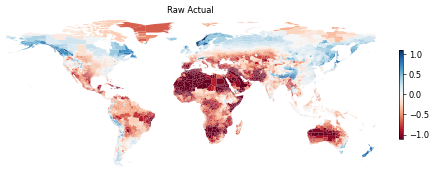

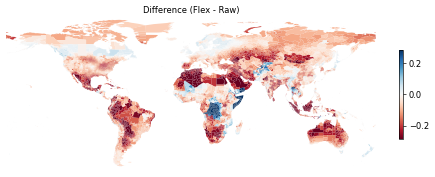

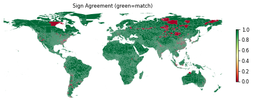

[interactive chart not shown]

Top 5 best predicted Top 5 worst predicted

Year 2098 · T<sub>mean</sub> across these regions: 4.51°C

| Region | Raw | Flex | Residual |
| --- | --- | --- | --- |
| AIA | 0 | 0 | 0 |
| BLM | 0 | 0 | 0 |
| BMU.R676c07148ce9acd1 | 0 | 0 | 0 |
| CCK | 0 | 0 | 0 |
| CXR | 0 | 0 | 0 |
| PER.7.67.676 | -0.216 | -0.999 | -0.782 |
| MAR.Re84a505a9b0896c1 | -1.04 | -1.72 | -0.679 |
| MAR.12.38.287.977 | -0.824 | -1.47 | -0.645 |
| MAR.10.32.244.R0e00e1dc597eabb5 | -1.16 | -1.78 | -0.614 |
| YEM.12.150 | -1.31 | -0.703 | 0.608 |

**low**

**Correlation:** 0.9834 | **RMSE:** 0.086029 | **Sign agreement:** 95.6%

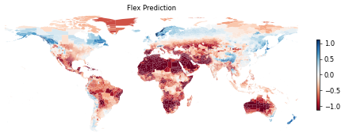

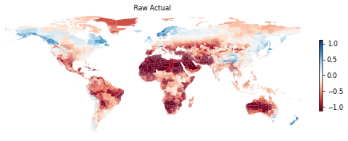

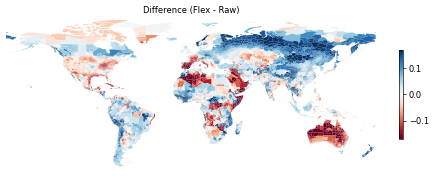

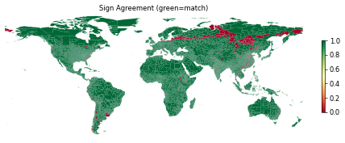

[interactive chart not shown]

Top 5 best predicted Top 5 worst predicted

Year 2098 · T<sub>mean</sub> across these regions: 4.51°C

| Region | Raw | Flex | Residual |
| --- | --- | --- | --- |
| AIA | 0 | 0 | 0 |
| BLM | 0 | 0 | 0 |
| BMU.R676c07148ce9acd1 | 0 | 0 | 0 |
| CCK | 0 | 0 | 0 |
| CXR | 0 | 0 | 0 |
| GUM.Rbf31fb14df17d835 | -0.571 | -1.08 | -0.505 |
| YEM.7.R07c491bf26980f92 | -0.725 | -1.15 | -0.424 |
| YEM.12.150 | -0.347 | -0.763 | -0.416 |
| YEM.5.R4348d27eca5354a1 | -0.47 | -0.883 | -0.413 |
| YEM.1.1 | -0.343 | -0.745 | -0.402 |

**Note · countries with no rice data** (shown white on every map above; the GCP rice pipeline does not run sims for non-producing countries): ATA, BVT, CL-, HMD, IOT, SGS, SP-.

## 10.1 Scenario Summary

Table 7: Fit statistics across all 12 scenarios

| RCP | SSP | Model | N | Corr | RMSE | Sign% |
| --- | --- | --- | --- | --- | --- | --- |
| rcp45 | SSP2 | high | 24,326 | 0.9296 | 0.10002 | 93.5% |
| rcp45 | SSP2 | low | 24,326 | 0.9527 | 0.081901 | 94.4% |
| rcp45 | SSP3 | high | 24,326 | 0.9483 | 0.074326 | 94.1% |
| rcp45 | SSP3 | low | 24,326 | 0.9587 | 0.067301 | 93.8% |
| rcp45 | SSP4 | high | 24,326 | 0.9486 | 0.076233 | 93.4% |
| rcp45 | SSP4 | low | 24,326 | 0.96 | 0.068115 | 93.5% |
| rcp85 | SSP2 | high | 24,326 | 0.9614 | 0.175077 | 95.3% |
| rcp85 | SSP2 | low | 24,326 | 0.9809 | 0.12529 | 96.7% |
| rcp85 | SSP3 | high | 24,326 | 0.9807 | 0.093523 | 95.9% |
| rcp85 | SSP3 | low | 24,326 | 0.9765 | 0.097375 | 96.5% |
| rcp85 | SSP4 | high | 24,326 | 0.9755 | 0.145349 | 93.1% |
| rcp85 | SSP4 | low | 24,326 | 0.9834 | 0.086029 | 95.6% |

# 11 Data Reference

## 11.1 File Locations

| Item | Path |
| --- | --- |
| Regional CSV | `/project/cil/gcp/flex_damage_funcs/parameters/agriculture__rice__regional_parameters.csv` |
| Global JSON | `/project/cil/gcp/flex_damage_funcs/parameters/agriculture__rice__global_results.json` |
| Metadata JSON | `/project/cil/gcp/flex_damage_funcs/parameters/agriculture__rice__metadata.json` |

## 11.2 Column Definitions

| Column | Description |
| --- | --- |
| `region` | Region identifier (hierarchical code, first 3 chars = country ISO3) |
| `gamma` | Income elasticity quantile value |
| `alpha` | Linear temperature coefficient |
| `beta` | Quadratic temperature coefficient |
| `sigma11` | Var(alpha) |
| `sigma12` | Cov(alpha, beta) |
| `sigma22` | Var(beta) |
| `rho` | Correlation with global residual process |
| `zeta` | Temperature-dependent heteroskedasticity |
| `eta` | Residual standard deviation |
| `rsqr1` | R-squared of polynomial fit |
| `rsqr2` | R-squared of error model |

*Report generated with FlexDamage v1.0.0*